# Hierarchical modelling

SHARP Bayesian Modeling for Environmental Health Workshop

Theo Rashid, Elizaveta Semenova

August 2023

```
## here() starts at /Users/es/Dropbox/00 Oxford/70_Robbie_workshop_SHARP/sharp_bayesian_environmental_health_2023
```

[output not shown]

```
## This is posterior version 1.4.1
##
##
```

[output not shown]

This task will involve taking the England or Italy data and fitting a really basic hierarchical model. It will follow your basic:

- Full pooling
- No pooling
- Partial pooling

Aka radon model example. https://www.tensorflow.org/probability/examples/Multilevel_Modeling_Primer The difference being our subgroups will be regions of Italy.

## Exploratory data analysis

```r
data <- read_rds(here("data", "italy", "italy_mortality.rds")) |> ungroup()
glimpse(data)
```

```
## Rows: 96,300
## Columns: 13
## $ NOME_PROVINCIA          <chr> "Agrigento", "Agrigento", "Agrigento", "Agrige…
## $ SIGLA                   <chr> "AG", "AG", "AG", "AG", "AG", "AG", "AG", "AG"…
## $ date                    <date> 2013-05-04, 2013-05-05, 2013-05-06, 2013-05-0…
## $ deaths                  <dbl> 11, 11, 12, 8, 10, 9, 14, 14, 5, 12, 10, 11, 9…
## $ year                    <dbl> 2013, 2013, 2013, 2013, 2013, 2013, 2013, 2013…
## $ expected                <dbl> 11.75367, 11.75367, 11.75367, 11.75367, 11.753…
## $ hol                     <dbl> 0, 0, 0, 0, 0, 0, 0, 0, 0, 0, 0, 0, 0, 0, 0, 0…
## $ month                   <dbl> 5, 5, 5, 5, 5, 5, 5, 5, 5, 5, 5, 5, 5, 5, 5, 5…
## $ temperature_lag0_3      <dbl> 20.47926, 20.25625, 20.00277, 18.80698, 17.427…
## $ relativehumidity_lag0_3 <dbl> 41.23675, 49.12295, 54.27453, 56.57282, 63.886…
## $ o3_lag0_3               <dbl> 101.69444, 98.83333, 99.25000, 100.05556, 104.…
## $ pm10_lag0_3             <dbl> 40.13326, 39.26412, 35.22450, 29.67259, 26.707…
## $ week                    <dbl> 18, 18, 18, 19, 19, 19, 19, 19, 19, 19, 20, 20…
```

```r
summary(data)
```

```
##  NOME_PROVINCIA        SIGLA                date                deaths
##  Length:96300       Length:96300       Min.   :2013-05-04   Min.   :  0.00
##  Class :character   Class :character   1st Qu.:2014-07-17   1st Qu.:  7.00
##  Mode  :character   Mode  :character   Median :2016-01-16   Median : 11.00
##                                        Mean   :2016-01-16   Mean   : 14.93
##                                        3rd Qu.:2017-07-17   3rd Qu.: 17.00
##                                        Max.   :2018-09-30   Max.   :272.00
##       year         expected            hol              month
##  Min.   :2013   Min.   :  2.909   Min.   :0.00000   Min.   :5.000
##  1st Qu.:2014   1st Qu.:  8.231   1st Qu.:0.00000   1st Qu.:6.000
##  Median :2016   Median : 11.674   Median :0.00000   Median :7.000
##  Mean   :2016   Mean   : 16.223   Mean   :0.01333   Mean   :7.033
##  3rd Qu.:2017   3rd Qu.: 18.153   3rd Qu.:0.00000   3rd Qu.:8.000
##  Max.   :2018   Max.   :118.261   Max.   :1.00000   Max.   :9.000
##  temperature_lag0_3 relativehumidity_lag0_3   o3_lag0_3       pm10_lag0_3
##  Min.   :-2.582     Min.   :24.01           Min.   :  1.00   Min.   : 2.917
##  1st Qu.:17.029     1st Qu.:63.92           1st Qu.: 96.06   1st Qu.:14.375
##  Median :20.380     Median :71.47           Median :108.38   Median :18.333
##  Mean   :19.996     Mean   :70.76           Mean   :111.35   Mean   :19.200
##  3rd Qu.:23.346     3rd Qu.:78.49           3rd Qu.:123.50   3rd Qu.:22.875
##  Max.   :32.962     Max.   :96.78           Max.   :257.50   Max.   :92.226
##       week
##  Min.   :18.0
##  1st Qu.:23.0
##  Median :29.0
##  Mean   :28.8
##  3rd Qu.:34.0
##  Max.   :40.0
```

Let’s collapse the time dimension for now and focus on estimating the death rate in the final year and the 9th month.

```r
data <- data |>
  mutate(provincia_id = data |> group_by(SIGLA) |> group_indices()) |>
  filter(year == 2018) |>
  filter(month == 9)
```

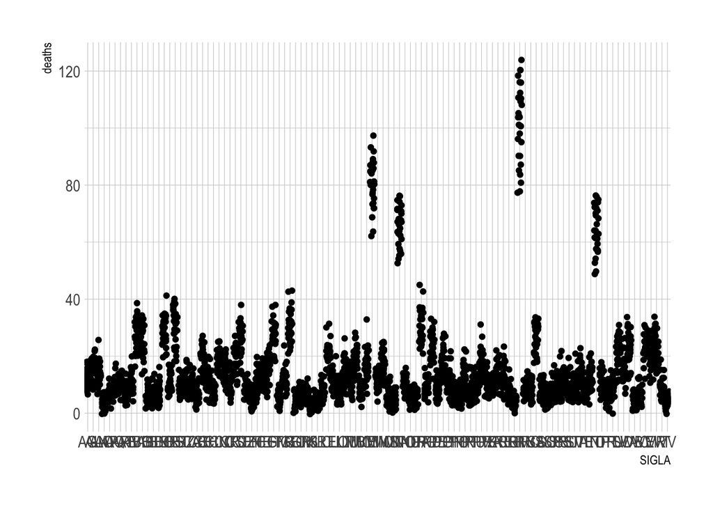

```r
data |>
  ggplot(aes(x = SIGLA, y = deaths)) +
  geom_jitter()
```

We have a variable `expected`, which gives a good approximation to the number of deaths

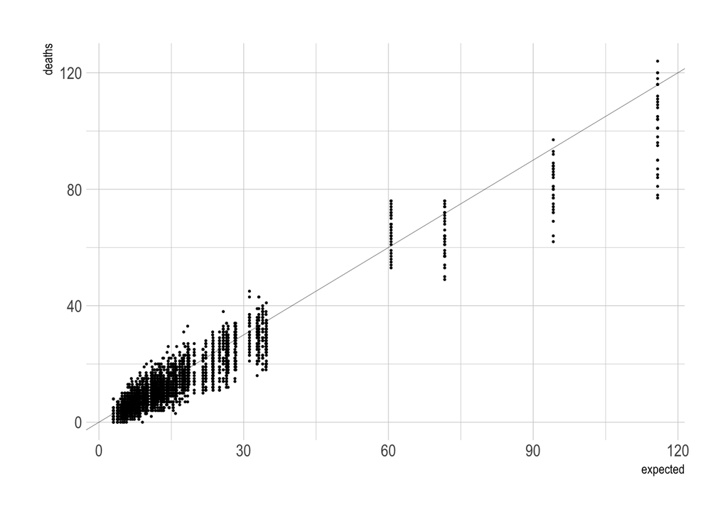

```r
data |>
  ggplot(aes(x = expected, y = deaths)) +
  geom_abline(slope = 1, intercept = 0, linewidth = 0.1) +
  geom_point(size = 0.3)
```

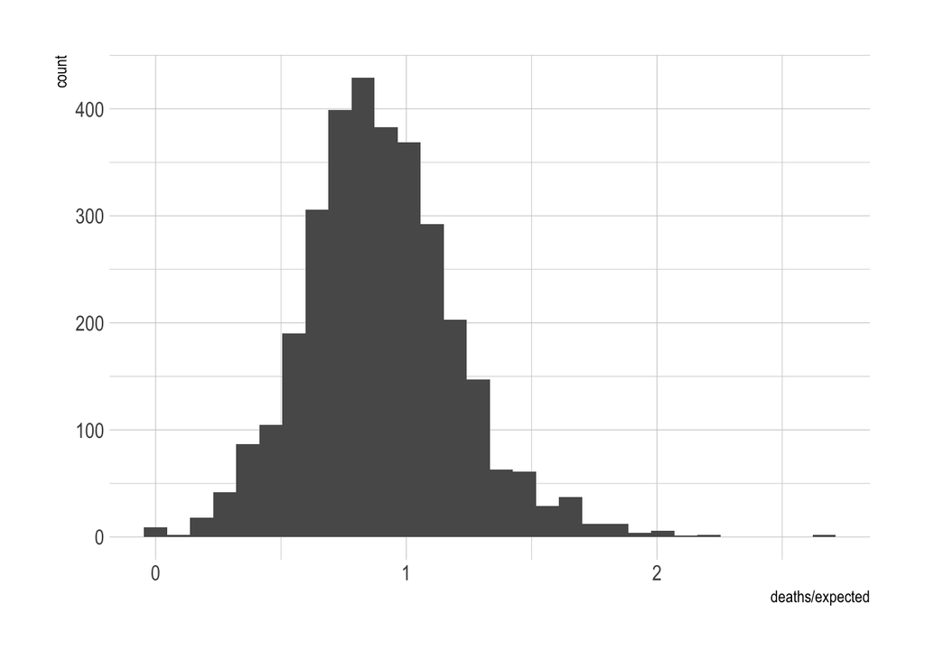

```r
data |>
  ggplot(aes(x = deaths / expected)) +
  geom_histogram()
```

Estimate the region-specific death rate/relative risk/excess?

## Full pooling model

Treat all regions the same and estimate a single national prevalence.

Priors
$$\alpha \sim N(0,5), \\
\sigma \sim N^+(1),\\
\theta \sim N(0, \sigma^2),$$
Likelihood:
$$\text{log}(\mu_i) = \text{log}(E_i) + \alpha + \theta,\\
y_i \sim \text{Pois}(\mu_i),\\
i=1,..., N$$
Parameter $\theta$ here is common for all observations $y_i$, regardless of what province the observation belongs to.

## No pooling model

Treat all regions separately and estimate each region separately with fixed effects.

$$\alpha \sim N(0,5), \\
\sigma \sim N^+(1),\\
\theta_i \sim N(0, \sigma^2),$$
Likelihood:
$$\text{log}(\mu_i) = \text{log}(E_i) + \alpha + \theta_i,\\
y_i \sim \text{Pois}(\mu_i),\\
i=1,..., N$$

## Partial pooling model

Varying intercepts model. Random effect grouping all regions. Estimate hyperparamter sigma (explain how this is hierarchical)

Priors:
$$\alpha \sim N(0,5), \\
\sigma_p \sim N^+(1),\\
\theta_j \sim N(0, \sigma^2_p), \quad j=1,..., N_p$$

Likelihood:
$$y_i \sim \text{Pois}(\mu_i),\\
\text{log}(\mu_i) = \text{log}(E_i) + \alpha + \theta_j\\
i=1,..., N \quad (observation) \\
j=1,..., N_p \quad (province)$$

```r
constants <- list(
  N = nrow(data),
  Np = max(data$provincia_id),
  province = data$provincia_id
)

inits <- list(
  alpha = 0,
  theta = rep(0, constants$Np),
  sigma_p = 1
)

nimble_data <- list(
  y = as.integer(data$deaths),
  E = data$expected
)
```

```r
partial_pooling_model <- nimbleCode({
  # priors
  alpha ~ dnorm(0, 5)
  sigma_p ~ T(dnorm(0, 1), 0, Inf) # half-normal

  for (j in 1:Np) {
    theta[j] ~ dnorm(0, sd = sigma_p)
  }

  # likelihood
  for (i in 1:N) {
    y[i] ~ dpois(mu[i])
    log(mu[i]) <- log(E[i]) + alpha + theta[province[i]]
  }
})
```